# Welcome to Jingyu Ma's game analysis ,this analysis is based on [a Steam game data that includes all the games published on Steam upto 2025 May.](https://www.kaggle.com/datasets/fronkongames/steam-gam

**1. Executive Summary** Based on analysis of 88,205 paid games, an optimal pricing range of USD 15-30 is recommended to balance revenue, player satisfaction, and market positioning. The Value tier (USD 5-10) shows the highest conversion rate (90.4%), while the Luxury tier (USD 60+) demonstrates significant player resistance (66.3% conversion).

**2. Key Findings**

**Price Tier Performance:**

- Value (USD 5-10): Highest conversion (90.4%), low sensitivity (0.107)
- Standard (USD 10-20): Strong conversion (88.5%), moderate quality (6.71 avg score)
- Premium (USD 20-30): Good conversion (86.5%), high quality (10.20 avg score)
- Luxury (USD 60+): Poor conversion (66.3%), low quality (1.38 avg score)

**Cluster Analysis Reveals Four Market Segments:**

- Cluster 0 (84k games): Mass market, low price (USD 8.07), low quality
- Cluster 1 (3.7k games): Premium segment, optimal price (USD 16.65), high quality (72.62 score)
- Cluster 2 (36 games): Blockbuster titles, high engagement (419k avg positives)
- Cluster 3 (274 games): Overpriced segment (USD 163.25), poor quality

**3. Price Sensitivity Analysis** The USD 5-10 range shows lowest sensitivity ratio (0.107), indicating strongest price acceptance. Sensitivity increases significantly above USD 10 (0.155) and below USD 3 (0.190).

**4. Recommended Strategy**

- **Mass Market Positioning:** Price at USD 5-10 for maximum conversion
- **Premium Positioning:** Target USD 15-30 for quality-value balance
- **Avoid:** Pricing above USD 60 due to severe conversion degradation
- **Genre Considerations:** Adjust pricing based on genre expectations and quality delivery

This analysis demonstrates that optimal pricing requires balancing actual game quality with player value perception, with the USD 15-30 range offering the best equilibrium for quality-focused developers.

## 4. 💼 Commercial Value Analysis

- Pricing strategy analysis
  - Correlation between price and ratings
  - Price tiers analysis and optimal pricing strategies
- DLC strategy analysis
  - Relationship between DLC count and game popularity
- Developer/Publisher analysis
  - Top developers statistics
  - Top publishers statistics
  - Developer market share
  - Publisher market share

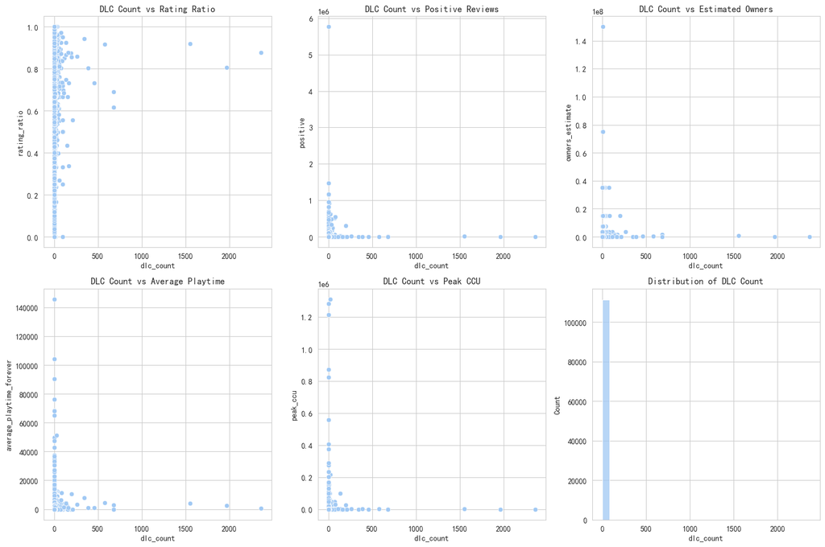

```
Correlation coefficients between the number of DLCs and various indicators:
rating_ratio: 0.001
positive: 0.020
owners_estimate: 0.025
average_playtime_forever: 0.036
peak_ccu: 0.009
```

```python
# 数据预处理
# 处理estimated_owners字段（可能需要转换为数值）
def parse_owners(owner_str):
    if pd.isna(owner_str):
        return np.nan
    parts = owner_str.split(' - ')
    if len(parts) == 2:
        return (int(parts[0].replace(',', '')) + int(parts[1].replace(',', ''))) / 2
    return np.nan

df['owners_estimate'] = df['estimated_owners'].apply(parse_owners)

# 计算评价比率
df['rating_ratio'] = df['positive'] / (df['positive'] + df['negative'])

# 分析DLC数量与受欢迎指标的关系
plt.figure(figsize=(15, 10))

# 1. DLC数量与评价比率的关系
plt.subplot(2, 3, 1)
sns.scatterplot(x='dlc_count', y='rating_ratio', data=df)
plt.title('DLC Count vs Rating Ratio')

# 2. DLC数量与正面评价数量的关系
plt.subplot(2, 3, 2)
sns.scatterplot(x='dlc_count', y='positive', data=df)
plt.title('DLC Count vs Positive Reviews')

# 3. DLC数量与估计拥有者数量的关系
plt.subplot(2, 3, 3)
sns.scatterplot(x='dlc_count', y='owners_estimate', data=df)
plt.title('DLC Count vs Estimated Owners')

# 4. DLC数量与平均游戏时长的关系
plt.subplot(2, 3, 4)
sns.scatterplot(x='dlc_count', y='average_playtime_forever', data=df)
plt.title('DLC Count vs Average Playtime')

# 5. DLC数量与同时在线峰值的关系
plt.subplot(2, 3, 5)
sns.scatterplot(x='dlc_count', y='peak_ccu', data=df)
plt.title('DLC Count vs Peak CCU')

# 6. DLC数量的分布
plt.subplot(2, 3, 6)
sns.histplot(df['dlc_count'], bins=30)
plt.title('Distribution of DLC Count')

plt.tight_layout()
plt.show()

# 计算相关系数
correlation_metrics = ['rating_ratio', 'positive', 'owners_estimate',
                      'average_playtime_forever', 'peak_ccu']

correlations = {}
for metric in correlation_metrics:
    if metric in df.columns:
        corr = df['dlc_count'].corr(df[metric])
        correlations[metric] = corr

print("Correlation coefficients between the number of DLCs and various indicators:")
for metric, corr in correlations.items():
    print(f"{metric}: {corr:.3f}")
```

```python
# 1. 查看DLC数量的分布
print("Descriptive statistics of DLC count:")
print(df['dlc_count'].describe())

# 2. 按DLC数量分组分析
dlc_groups = pd.cut(df['dlc_count'], bins=[-1, 0, 1, 5, 10, 100, 1000])
grouped = df.groupby(dlc_groups,observed=False).agg({
    'rating_ratio': 'mean',
    'positive': 'mean',
    'owners_estimate': 'mean',
    'average_playtime_forever': 'mean'
})
print("\nAverage indicators grouped by the number of DLCs:")
print(grouped)

# 3. 分析有无DLC的差异
df['has_dlc'] = df['dlc_count'] > 0
dlc_vs_no_dlc = df.groupby('has_dlc').agg({
    'rating_ratio': 'mean',
    'positive': 'mean',
    'owners_estimate': 'mean'
})
print("\nHaving DLC vs without DLC comparison :")
print(dlc_vs_no_dlc)
```

```
Descriptive statistics of DLC count:
count    111452.000000
mean          0.449530
std          12.006677
min           0.000000
25%           0.000000
50%           0.000000
75%           0.000000
max        2366.000000
Name: dlc_count, dtype: float64

Average indicators grouped by the number of DLCs:
             rating_ratio      positive  owners_estimate  \
dlc_count
(-1, 0]          0.755208    282.443318     3.953096e+04
(0, 1]           0.814713   2522.299431     1.593887e+05
(1, 5]           0.793004   3929.763782     3.271185e+05
(5, 10]          0.767455  10058.937611     7.591889e+05
(10, 100]        0.765496  26977.807054     1.403537e+06
(100, 1000]      0.720577  18239.730769     1.156731e+06

             average_playtime_forever
dlc_count
(-1, 0]                     48.157923
(0, 1]                     171.174165
(1, 5]                     455.948336
(5, 10]                    690.741533
(10, 100]                 1381.943983
(100, 1000]               1747.269231

Having DLC vs without DLC comparison :
         rating_ratio     positive  owners_estimate
has_dlc
False        0.755208   282.443318     39530.962035
True         0.804792  4098.115496    274912.579803
```

# Analysis of DLC Count and Game Popularity Relationship

## Key Findings from Grouped Analysis

### 1. **Data Distribution Characteristics**

From descriptive statistics:

- **75% of games have no DLC** (75th percentile is 0)
- **Average DLC count is 0.45**, but with large standard deviation (12.0), indicating highly uneven distribution
- **Maximum DLC count reaches 2,366**, showing extreme outliers exist

### 2. **Significant Difference: Games With vs Without DLC**

```
Games WITH DLC: Rating ratio 0.805, Positive reviews 4,098, Estimated players 274,912
Games WITHOUT DLC: Rating ratio 0.755, Positive reviews 282, Estimated players 39,531
```

**Conclusion**: Games with DLC significantly outperform those without DLC across all metrics:

- **6.5% higher rating ratio** → Higher player satisfaction
- **14.5x more positive reviews** → Much higher popularity
- **7x more players** → Greater commercial success

### 3. **Sweet Spot Analysis by DLC Quantity**

| DLC Count Range | Rating Ratio | Positive Reviews | Player Count | Playtime |
| --- | --- | --- | --- | --- |
| 0 DLCs | 0.755 | 282 | 39,531 | 48 min |
| **1-5 DLCs** | **0.793** | **3,930** | **327,118** | **456 min** |
| 5-10 DLCs | 0.767 | 10,059 | 759,189 | 691 min |
| 10-100 DLCs | 0.765 | 26,978 | 1,403,537 | 1,382 min |
| 100+ DLCs | 0.721 | 18,240 | 1,156,731 | 1,747 min |

## Important Business Insights

### 1. **"Having DLC" Matters More Than "DLC Quantity"**

- Simply having any DLC correlates with significantly better game performance
- However, excessive DLC quantity can reduce player satisfaction

### 4. **Playtime Positively Correlates with DLC Count**

- More DLCs = longer player engagement
- But requires balancing with player satisfaction metrics

## Strategic Recommendations

1. **Prioritize developing 1-5 high-quality DLCs** - this offers the best cost-benefit ratio
2. **Avoid DLC oversaturation** - be cautious when exceeding 10 DLCs
3. **For new games**, DLC strategy can serve as an important success indicator
4. **Focus on DLC quality rather than quantity**

## 4. 💼 Commercial Value Analysis

- Pricing strategy analysis
  - Correlation between price and ratings
  - Price tiers analysis and optimal pricing strategies
- DLC strategy analysis
  - Relationship between DLC count and game popularity
- Developer/Publisher analysis
  - Top developers statistics
  - Top publishers statistics
  - Developer market share
  - Publisher market share

```
Font set to: Microsoft JhengHei
Total game records: 104981
Expanded developer records: 114778
Unique developers count: 68569

=== Independent Developer Statistics ===
Number of developers analyzed: 15884
```

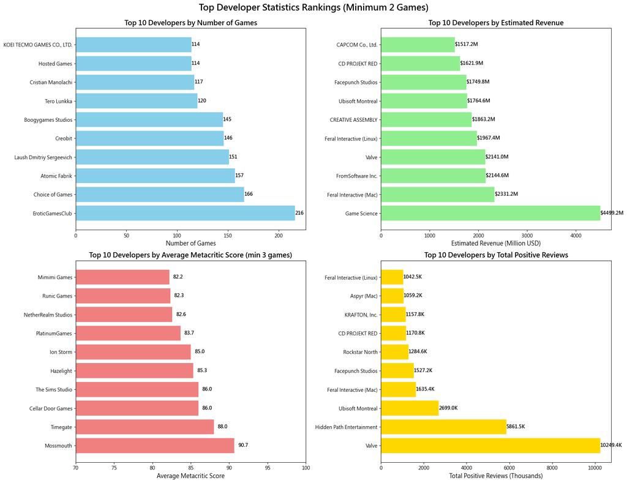

```python
# Set multilingual font support
def set_multilingual_font():
    cjk_fonts = [
        'Microsoft JhengHei', 'SimHei', 'Noto Sans CJK JP',
        'Noto Sans CJK KR', 'Noto Sans CJK SC', 'Arial Unicode MS'
    ]

    available_fonts = set(f.name for f in fm.fontManager.ttflist)

    for font_name in cjk_fonts:
        if font_name in available_fonts:
            plt.rcParams['font.family'] = [font_name]
            plt.rcParams['font.sans-serif'] = [font_name, 'DejaVu Sans', 'Arial']
            print(f"Font set to: {font_name}")
            break
    else:
        print("Warning: No suitable CJK font found, using default font")

    plt.rcParams['axes.unicode_minus'] = False

set_multilingual_font()

# Data preprocessing function
def parse_list_string(x):
    try:
        if isinstance(x, str):
            # Handle string-formatted lists
            if x.startswith('[') and x.endswith(']'):
                return ast.literal_eval(x)
            else:
                # If not in list format, return as single element list
                return [x]
        elif isinstance(x, list):
            return x
        elif pd.isna(x):
            return []
        else:
            return [str(x)]
    except:
        return [str(x)] if pd.notna(x) else []

# Convert developers column
df['developers'] = df['developers'].apply(parse_list_string)

# Filter out rows without developers
df = df[df['developers'].apply(lambda x: len(x) > 0)]

# Expand developers list, one developer per row
exploded_df = df.explode('developers')

# Clean developer names
exploded_df['developers'] = exploded_df['developers'].str.strip()
exploded_df = exploded_df[exploded_df['developers'] != '']
exploded_df = exploded_df[exploded_df['developers'].notna()]

print(f"Total game records: {len(df)}")
print(f"Expanded developer records: {len(exploded_df)}")
print(f"Unique developers count: {exploded_df['developers'].nunique()}")

# Calculate estimated revenue
def estimate_revenue(row):
    try:
        owners_str = str(row['estimated_owners'])
        if ' - ' in owners_str:
            owners_range = owners_str.split(' - ')
            if len(owners_range) == 2:
                min_owners = int(owners_range[0].replace(',', '').replace(' ', ''))
                max_owners = int(owners_range[1].replace(',', '').replace(' ', ''))
                avg_owners = (min_owners + max_owners) / 2
                return row['price'] * avg_owners
    except:
        pass
    return 0

exploded_df['estimated_revenue'] = exploded_df.apply(estimate_revenue, axis=1)
exploded_df['positive_ratio'] = exploded_df['positive'] / (exploded_df['positive'] + exploded_df['negative'] + 1e-10)

# Group statistics by developer
developer_stats = exploded_df.groupby('developers').agg({
    'name': 'count',  # Number of games
    'estimated_revenue': 'sum',  # Total revenue
    'metacritic_score': ['mean', 'count'],  # Average score and number of games with scores
    'positive': 'sum',  # Total positive reviews
    'average_playtime_forever': 'mean',  # Average playtime
    'peak_ccu': 'max',  # Maximum concurrent users
    'dlc_count': 'sum',  # Total DLC count
    'achievements': 'sum',  # Total achievements
    'price': 'mean'  # Average price
})

# Rename columns
developer_stats.columns = [
    'game_count', 'total_revenue', 'avg_metacritic_score',
    'games_with_metacritic', 'total_positive_reviews',
    'avg_playtime_hours', 'peak_ccu', 'total_dlc_count',
    'total_achievements', 'avg_price'
]

# Convert units
developer_stats['avg_playtime_hours'] = developer_stats['avg_playtime_hours'] / 60
developer_stats['total_revenue_millions'] = developer_stats['total_revenue'] / 1e6

# Filter out developers with too few games (at least 2 games)
developer_stats_filtered = developer_stats[developer_stats['game_count'] >= 2]

print("\n=== Independent Developer Statistics ===")
print(f"Number of developers analyzed: {len(developer_stats_filtered)}")

# Create visualizations
fig, axes = plt.subplots(2, 2, figsize=(18, 14))
fig.suptitle('Top Developer Statistics Rankings (Minimum 2 Games)', fontsize=18, fontweight='bold')

# 1. Rank by number of games
top_by_count = developer_stats_filtered.nlargest(10, 'game_count')
labels = [str(label)[:30] + '...' if len(str(label)) > 30 else str(label) for label in top_by_count.index]
bars1 = axes[0, 0].barh(labels, top_by_count['game_count'], color='skyblue')
axes[0, 0].set_title('Top 10 Developers by Number of Games', fontweight='bold', fontsize=14)
axes[0, 0].set_xlabel('Number of Games', fontsize=12)
for i, v in enumerate(top_by_count['game_count']):
    axes[0, 0].text(v + 0.1, i, str(int(v)), va='center', fontsize=10, fontweight='bold')

# 2. Rank by total revenue
top_by_revenue = developer_stats_filtered.nlargest(10, 'total_revenue_millions')
labels = [str(label)[:30] + '...' if len(str(label)) > 30 else str(label) for label in top_by_revenue.index]
bars2 = axes[0, 1].barh(labels, top_by_revenue['total_revenue_millions'], color='lightgreen')
axes[0, 1].set_title('Top 10 Developers by Estimated Revenue', fontweight='bold', fontsize=14)
axes[0, 1].set_xlabel('Estimated Revenue (Million USD)', fontsize=12)
for i, v in enumerate(top_by_revenue['total_revenue_millions']):
    axes[0, 1].text(v + 0.1, i, f'${v:.1f}M', va='center', fontsize=10, fontweight='bold')

# 3. Rank by average score (at least 3 games with scores)
qualified_devs = developer_stats_filtered[developer_stats_filtered['games_with_metacritic'] >= 3]
top_by_score = qualified_devs.nlargest(10, 'avg_metacritic_score')
labels = [str(label)[:30] + '...' if len(str(label)) > 30 else str(label) for label in top_by_score.index]
bars3 = axes[1, 0].barh(labels, top_by_score['avg_metacritic_score'], color='lightcoral')
axes[1, 0].set_title('Top 10 Developers by Average Metacritic Score (min 3 games)', fontweight='bold', fontsize=14)
axes[1, 0].set_xlabel('Average Metacritic Score', fontsize=12)
axes[1, 0].set_xlim(70, 100)
for i, v in enumerate(top_by_score['avg_metacritic_score']):
    axes[1, 0].text(v + 0.5, i, f'{v:.1f}', va='center', fontsize=10, fontweight='bold')

# 4. Rank by total positive reviews
top_by_positive = developer_stats_filtered.nlargest(10, 'total_positive_reviews')
labels = [str(label)[:30] + '...' if len(str(label)) > 30 else str(label) for label in top_by_positive.index]
positive_values = top_by_positive['total_positive_reviews'] / 1000  # Convert to thousands
bars4 = axes[1, 1].barh(labels, positive_values, color='gold')
axes[1, 1].set_title('Top 10 Developers by Total Positive Reviews', fontweight='bold', fontsize=14)
axes[1, 1].set_xlabel('Total Positive Reviews (Thousands)', fontsize=12)
for i, v in enumerate(positive_values):
    axes[1, 1].text(v + 0.1, i, f'{v:.1f}K', va='center', fontsize=10, fontweight='bold')

plt.tight_layout()
plt.subplots_adjust(top=0.93)
plt.show()
```

## 4. 💼 Commercial Value Analysis

- Pricing strategy analysis
  - Correlation between price and ratings
  - Price tiers analysis and optimal pricing strategies
- DLC strategy analysis
  - Relationship between DLC count and game popularity
- Developer/Publisher analysis
  - Top developers statistics
  - Top publishers statistics
  - Developer market share
  - Publisher market share)

```
Font set to: Microsoft JhengHei
Total game records: 104974
Expanded publisher records: 108489
Unique publishers count: 56986

=== Publisher Statistics ===
Number of publishers analyzed: 13239
```

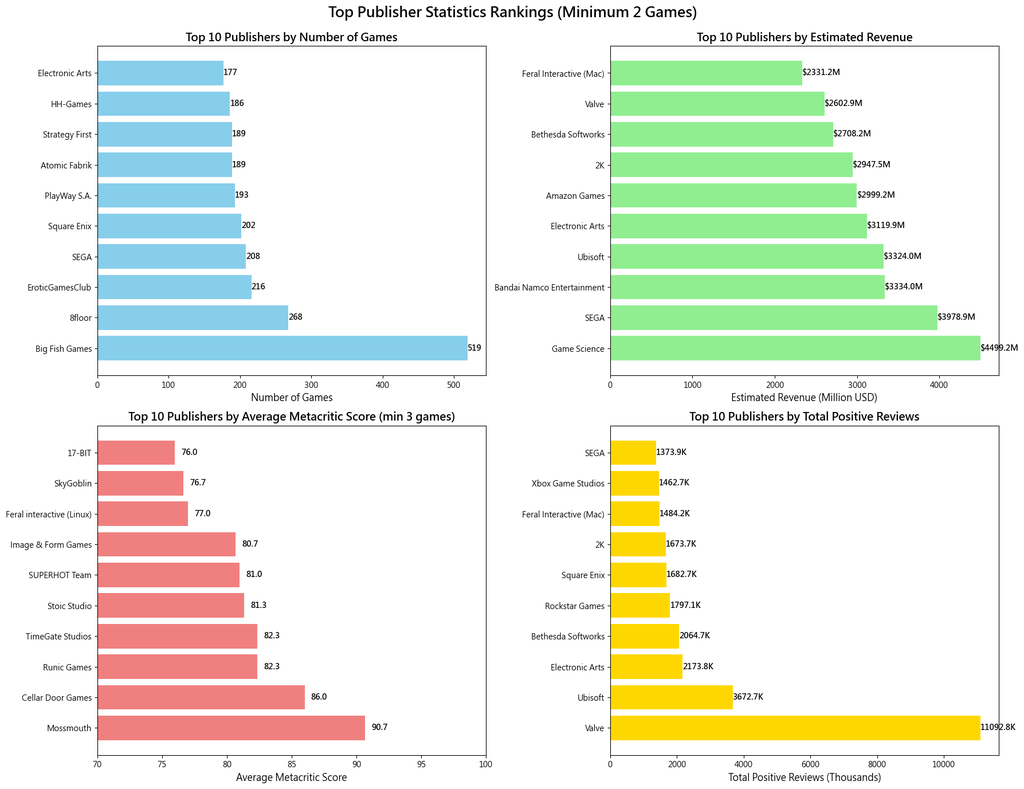

```python
def set_multilingual_font():
    cjk_fonts = [
        'Microsoft JhengHei', 'SimHei', 'Noto Sans CJK JP',
        'Noto Sans CJK KR', 'Noto Sans CJK SC', 'Arial Unicode MS'
    ]

    available_fonts = set(f.name for f in fm.fontManager.ttflist)

    for font_name in cjk_fonts:
        if font_name in available_fonts:
            plt.rcParams['font.family'] = [font_name]
            plt.rcParams['font.sans-serif'] = [font_name, 'DejaVu Sans', 'Arial']
            print(f"Font set to: {font_name}")
            break
    else:
        print("Warning: No suitable CJK font found, using default font")

    plt.rcParams['axes.unicode_minus'] = False

set_multilingual_font()

# Data preprocessing function for lists
def parse_list_string(x):
    try:
        if isinstance(x, str):
            # Handle string-formatted lists
            if x.startswith('[') and x.endswith(']'):
                return ast.literal_eval(x)
            else:
                # If not in list format, return as single element list
                return [x]
        elif isinstance(x, list):
            return x
        elif pd.isna(x):
            return []
        else:
            return [str(x)]
    except:
        return [str(x)] if pd.notna(x) else []

# Convert publishers column
df['publishers'] = df['publishers'].apply(parse_list_string)

# Filter out rows without publishers
df_publisher = df[df['publishers'].apply(lambda x: len(x) > 0)]

# Expand publishers list, one publisher per row
exploded_publisher_df = df_publisher.explode('publishers')

# Clean publisher names
exploded_publisher_df['publishers'] = exploded_publisher_df['publishers'].str.strip()
exploded_publisher_df = exploded_publisher_df[exploded_publisher_df['publishers'] != '']
exploded_publisher_df = exploded_publisher_df[exploded_publisher_df['publishers'].notna()]

print(f"Total game records: {len(df_publisher)}")
print(f"Expanded publisher records: {len(exploded_publisher_df)}")
print(f"Unique publishers count: {exploded_publisher_df['publishers'].nunique()}")

# Calculate estimated revenue
def estimate_revenue(row):
    try:
        owners_str = str(row['estimated_owners'])
        if ' - ' in owners_str:
            owners_range = owners_str.split(' - ')
            if len(owners_range) == 2:
                min_owners = int(owners_range[0].replace(',', '').replace(' ', ''))
                max_owners = int(owners_range[1].replace(',', '').replace(' ', ''))
                avg_owners = (min_owners + max_owners) / 2
                return row['price'] * avg_owners
    except:
        pass
    return 0

exploded_publisher_df['estimated_revenue'] = exploded_publisher_df.apply(estimate_revenue, axis=1)
exploded_publisher_df['positive_ratio'] = exploded_publisher_df['positive'] / (exploded_publisher_df['positive'] + exploded_publisher_df['negative'] + 1e-10)

# Group statistics by publisher
publisher_stats = exploded_publisher_df.groupby('publishers').agg({
    'name': 'count',  # Number of games
    'estimated_revenue': 'sum',  # Total revenue
    'metacritic_score': ['mean', 'count'],  # Average score and number of games with scores
    'positive': 'sum',  # Total positive reviews
    'average_playtime_forever': 'mean',  # Average playtime
    'peak_ccu': 'max',  # Maximum concurrent users
    'dlc_count': 'sum',  # Total DLC count
    'achievements': 'sum',  # Total achievements
    'price': 'mean'  # Average price
})

# Rename columns
publisher_stats.columns = [
    'game_count', 'total_revenue', 'avg_metacritic_score',
    'games_with_metacritic', 'total_positive_reviews',
    'avg_playtime_hours', 'peak_ccu', 'total_dlc_count',
    'total_achievements', 'avg_price'
]

# Convert units
publisher_stats['avg_playtime_hours'] = publisher_stats['avg_playtime_hours'] / 60
publisher_stats['total_revenue_millions'] = publisher_stats['total_revenue'] / 1e6

# Filter out publishers with too few games (at least 2 games)
publisher_stats_filtered = publisher_stats[publisher_stats['game_count'] >= 2]

print("\n=== Publisher Statistics ===")
print(f"Number of publishers analyzed: {len(publisher_stats_filtered)}")

# Create visualizations for publishers
fig, axes = plt.subplots(2, 2, figsize=(18, 14))
fig.suptitle('Top Publisher Statistics Rankings (Minimum 2 Games)', fontsize=18, fontweight='bold')

# 1. Rank by number of games
top_by_count = publisher_stats_filtered.nlargest(10, 'game_count')
labels = [str(label)[:30] + '...' if len(str(label)) > 30 else str(label) for label in top_by_count.index]
bars1 = axes[0, 0].barh(labels, top_by_count['game_count'], color='skyblue')
axes[0, 0].set_title('Top 10 Publishers by Number of Games', fontweight='bold', fontsize=14)
axes[0, 0].set_xlabel('Number of Games', fontsize=12)
for i, v in enumerate(top_by_count['game_count']):
    axes[0, 0].text(v + 0.1, i, str(int(v)), va='center', fontsize=10, fontweight='bold')

# 2. Rank by total revenue
top_by_revenue = publisher_stats_filtered.nlargest(10, 'total_revenue_millions')
labels = [str(label)[:30] + '...' if len(str(label)) > 30 else str(label) for label in top_by_revenue.index]
bars2 = axes[0, 1].barh(labels, top_by_revenue['total_revenue_millions'], color='lightgreen')
axes[0, 1].set_title('Top 10 Publishers by Estimated Revenue', fontweight='bold', fontsize=14)
axes[0, 1].set_xlabel('Estimated Revenue (Million USD)', fontsize=12)
for i, v in enumerate(top_by_revenue['total_revenue_millions']):
    axes[0, 1].text(v + 0.1, i, f'${v:.1f}M', va='center', fontsize=10, fontweight='bold')

# 3. Rank by average score (at least 3 games with scores)
qualified_pubs = publisher_stats_filtered[publisher_stats_filtered['games_with_metacritic'] >= 3]
top_by_score = qualified_pubs.nlargest(10, 'avg_metacritic_score')
labels = [str(label)[:30] + '...' if len(str(label)) > 30 else str(label) for label in top_by_score.index]
bars3 = axes[1, 0].barh(labels, top_by_score['avg_metacritic_score'], color='lightcoral')
axes[1, 0].set_title('Top 10 Publishers by Average Metacritic Score (min 3 games)', fontweight='bold', fontsize=14)
axes[1, 0].set_xlabel('Average Metacritic Score', fontsize=12)
axes[1, 0].set_xlim(70, 100)
for i, v in enumerate(top_by_score['avg_metacritic_score']):
    axes[1, 0].text(v + 0.5, i, f'{v:.1f}', va='center', fontsize=10, fontweight='bold')

# 4. Rank by total positive reviews
top_by_positive = publisher_stats_filtered.nlargest(10, 'total_positive_reviews')
labels = [str(label)[:30] + '...' if len(str(label)) > 30 else str(label) for label in top_by_positive.index]
positive_values = top_by_positive['total_positive_reviews'] / 1000  # Convert to thousands
bars4 = axes[1, 1].barh(labels, positive_values, color='gold')
axes[1, 1].set_title('Top 10 Publishers by Total Positive Reviews', fontweight='bold', fontsize=14)
axes[1, 1].set_xlabel('Total Positive Reviews (Thousands)', fontsize=12)
for i, v in enumerate(positive_values):
    axes[1, 1].text(v + 0.1, i, f'{v:.1f}K', va='center', fontsize=10, fontweight='bold')

plt.tight_layout()
plt.subplots_adjust(top=0.93)
plt.show()
```

## 4. 💼 Commercial Value Analysis

- Pricing strategy analysis
  - Correlation between price and ratings
  - Price tiers analysis and optimal pricing strategies
- DLC strategy analysis
  - Relationship between DLC count and game popularity
- Developer/Publisher analysis
  - Top developers statistics
  - Top publishers statistics
  - Developer market share
  - Publisher market share

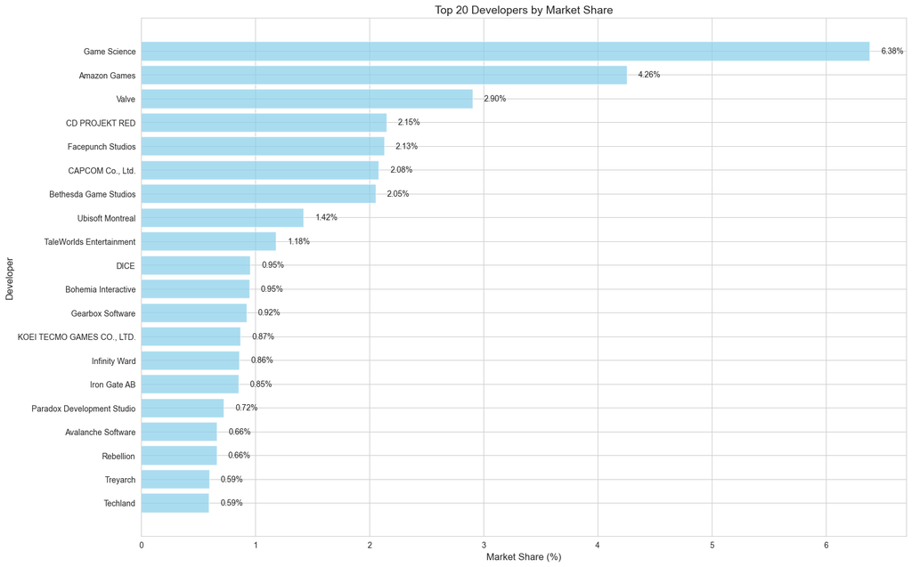

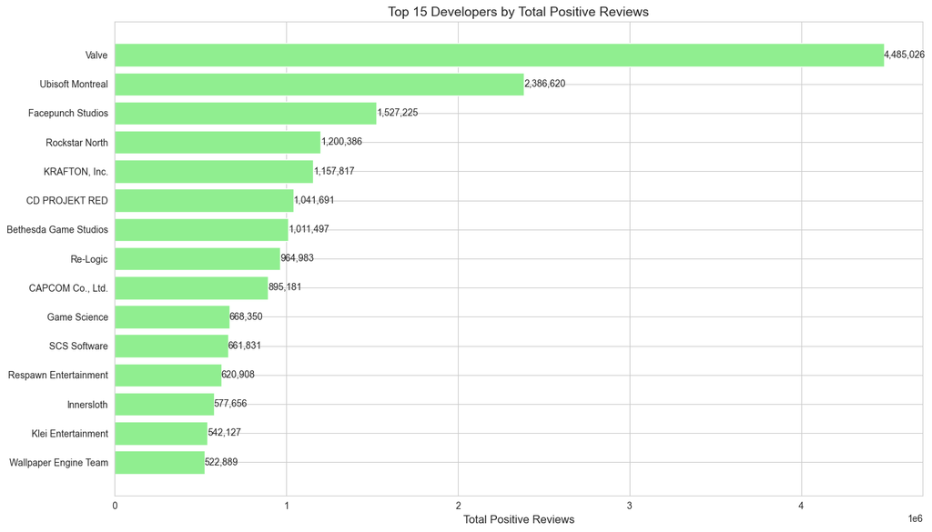

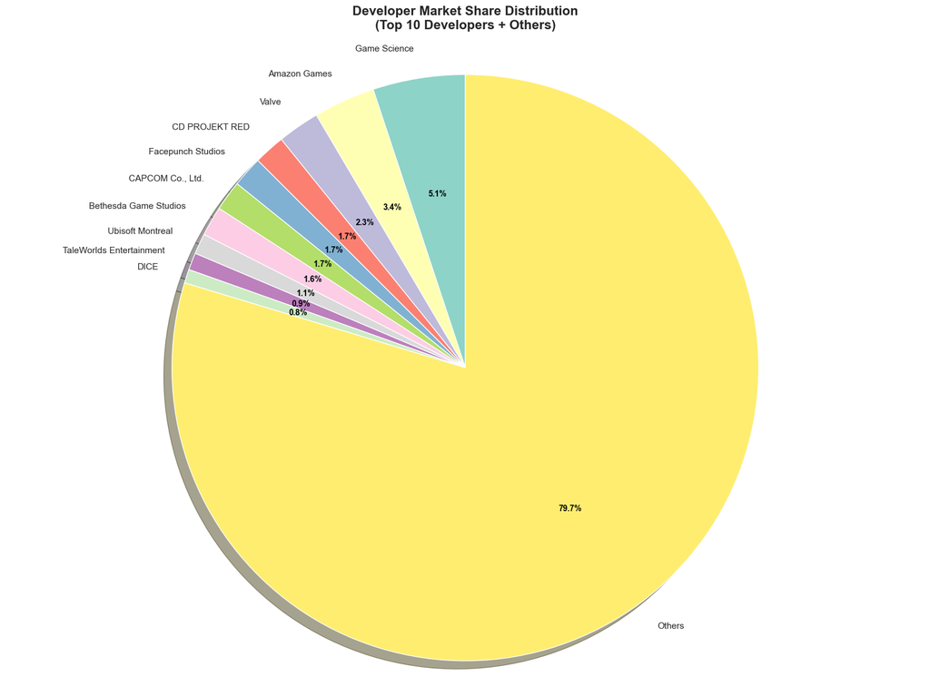

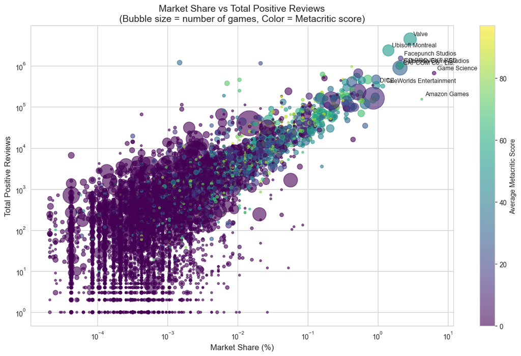

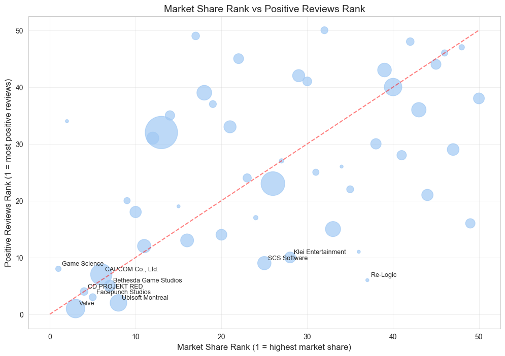

```python
# 设置字体和解决负号显示问题
mpl.rcParams['font.family'] = 'DejaVu Sans'
mpl.rcParams['axes.unicode_minus'] = False

# 或者使用更具体的设置
plt.rcParams['font.sans-serif'] = ['DejaVu Sans', 'Arial', 'Helvetica', 'sans-serif']
plt.rcParams['axes.unicode_minus'] = False

# 剩余代码保持不变...
sns.set_style("whitegrid")  # 设置seaborn样式

# 数据预处理
def safe_literal_eval(x):
    try:
        if pd.isna(x):
            return []
        return ast.literal_eval(x) if isinstance(x, str) else x
    except:
        return []

df['developers'] = df['developers'].apply(safe_literal_eval)
df = df[df['developers'].apply(len) > 0]

# 展开开发者列表
exploded_df = df.explode('developers')

# 提取最小用户数
def extract_owners_min(owners_str):
    if pd.isna(owners_str):
        return 0
    try:
        if ' - ' in owners_str:
            return int(owners_str.split(' - ')[0].replace(',', '').replace(' ', ''))
        else:
            return int(owners_str.replace(',', ''))
    except:
        return 0

exploded_df['min_owners'] = exploded_df['estimated_owners'].apply(extract_owners_min)
exploded_df['estimated_revenue'] = exploded_df['price'] * exploded_df['min_owners']

# 修正：正确的聚合方式，避免列名重复
developer_stats = exploded_df.groupby('developers').agg({
    'name': 'count',
    'price': 'mean',
    'min_owners': 'sum',
    'estimated_revenue': 'sum',
    'metacritic_score': 'mean',
    'positive': 'sum',  # 总好评数量
    'negative': 'sum'   # 总差评数量
}).reset_index()

# 正确的列名设置
developer_stats.columns = ['developer', 'game_count', 'avg_price', 'total_owners',
                          'estimated_revenue', 'avg_metacritic', 'total_positive', 'total_negative']

# 计算市场份额
total_revenue = developer_stats['estimated_revenue'].sum()
developer_stats['market_share'] = (developer_stats['estimated_revenue'] / total_revenue) * 100
developer_stats['revenue_rank'] = developer_stats['estimated_revenue'].rank(ascending=False)

# 计算总评价数量
developer_stats['total_reviews'] = developer_stats['total_positive'] + developer_stats['total_negative']

# 1. 前20大开发者市场份额和总好评数量
top_20_developers = developer_stats.nlargest(20, 'market_share')

fig, ax1 = plt.subplots(figsize=(16, 10))

# 市场份额柱状图
bars = ax1.barh(top_20_developers['developer'], top_20_developers['market_share'], alpha=0.7, color='skyblue')
ax1.set_xlabel('Market Share (%)', fontsize=12)
ax1.set_ylabel('Developer', fontsize=12)
ax1.set_title('Top 20 Developers by Market Share', fontsize=14)

# 添加市场份额数值标签
for bar in bars:
    width = bar.get_width()
    ax1.text(width + 0.1, bar.get_y() + bar.get_height()/2,
             f'{width:.2f}%', ha='left', va='center', fontsize=10)

plt.gca().invert_yaxis()
plt.tight_layout()
plt.show()

# 2. 前15大开发者总好评数量
top_15_positive = developer_stats.nlargest(15, 'total_positive')

plt.figure(figsize=(14, 8))
bars = plt.barh(top_15_positive['developer'], top_15_positive['total_positive'], color='lightgreen')
plt.xlabel('Total Positive Reviews', fontsize=12)
plt.title('Top 15 Developers by Total Positive Reviews', fontsize=14)


# 添加好评数量数值标签
for bar in bars:
    width = bar.get_width()
    plt.text(width + 0.1, bar.get_y() + bar.get_height()/2,
             f'{width:,.0f}', ha='left', va='center', fontsize=10)

plt.gca().invert_yaxis()
plt.tight_layout()
plt.show()


top_10_developers = developer_stats.nlargest(10, 'market_share')
others_dev = pd.DataFrame({
    'developer': ['Others'],
    'market_share': [developer_stats['market_share'][10:].sum()]
})
pie_data_dev = pd.concat([top_10_developers[['developer', 'market_share']], others_dev])

# 更美观的Developer市场份额饼图
plt.figure(figsize=(16, 12))
colors = plt.cm.Set3(np.linspace(0, 1, len(pie_data_dev)))
wedges, texts, autotexts = plt.pie(pie_data_dev['market_share'],
                                  labels=pie_data_dev['developer'],
                                  autopct='%1.1f%%',
                                  colors=colors,
                                  startangle=90,
                                  shadow=True)

# 美化文本
for autotext in autotexts:
    autotext.set_color('black')
    autotext.set_fontsize(10)
    autotext.set_fontweight('bold')

for text in texts:
    text.set_fontsize(11)

plt.title('Developer Market Share Distribution\n(Top 10 Developers + Others)',
          fontsize=16, fontweight='bold', pad=20)
plt.axis('equal')  # 确保饼图是圆形
plt.tight_layout()
plt.show()

# 3. 散点图：市场份额 vs 总好评数量
plt.figure(figsize=(14, 8))

# 过滤掉没有好评的开发者
filtered_stats = developer_stats[developer_stats['total_positive'] > 0]

scatter = plt.scatter(filtered_stats['market_share'], filtered_stats['total_positive'],
                     s=filtered_stats['game_count']*10, alpha=0.6,
                     c=filtered_stats['avg_metacritic'], cmap='viridis')

plt.xlabel('Market Share (%)', fontsize=12)
plt.ylabel('Total Positive Reviews', fontsize=12)
plt.title('Market Share vs Total Positive Reviews\n(Bubble size = number of games, Color = Metacritic score)', fontsize=14)
plt.colorbar(label='Average Metacritic Score')

# 标注前10大开发者
for i, row in filtered_stats.nlargest(10, 'market_share').iterrows():
    plt.annotate(row['developer'], (row['market_share'], row['total_positive']),
                xytext=(5, 5), textcoords='offset points', fontsize=9)

plt.xscale('log')
plt.yscale('log')
plt.show()

# 4. 双排名图：市场份额排名 vs 好评数量排名
top_50 = developer_stats.nlargest(50, 'market_share').copy()
top_50['market_share_rank'] = range(1, len(top_50) + 1)
top_50 = top_50.sort_values('total_positive', ascending=False)
top_50['positive_rank'] = range(1, len(top_50) + 1)

plt.figure(figsize=(12, 8))
plt.scatter(top_50['market_share_rank'], top_50['positive_rank'],
           s=top_50['game_count']*20, alpha=0.7)

# 添加对角线
max_rank = max(top_50['market_share_rank'].max(), top_50['positive_rank'].max())
plt.plot([0, max_rank], [0, max_rank], 'r--', alpha=0.5)

# 标注一些重要的开发者
for i, row in top_50.head(10).iterrows():
    plt.annotate(row['developer'], (row['market_share_rank'], row['positive_rank']),
                xytext=(5, 5), textcoords='offset points', fontsize=9)

plt.xlabel('Market Share Rank (1 = highest market share)', fontsize=12)
plt.ylabel('Positive Reviews Rank (1 = most positive reviews)', fontsize=12)
plt.title('Market Share Rank vs Positive Reviews Rank', fontsize=14)
plt.grid(True, alpha=0.3)
plt.show()
```

## 4. 💼 Commercial Value Analysis

- Pricing strategy analysis
  - Correlation between price and ratings
  - Price tiers analysis and optimal pricing strategies
- DLC strategy analysis
  - Relationship between DLC count and game popularity
- Developer/Publisher analysis
  - Top developers statistics
  - Top publishers statistics
  - Developer market share
  - Publisher market share

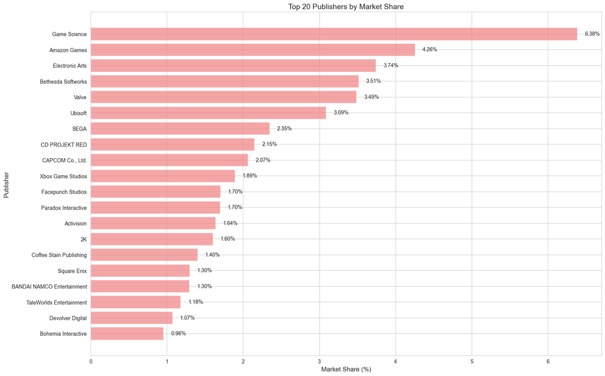

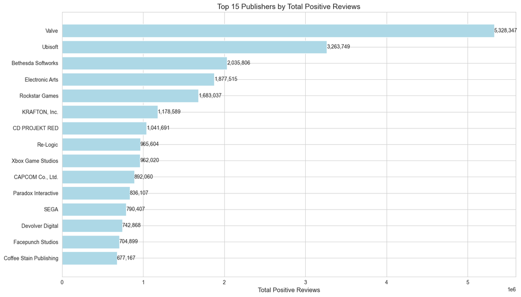

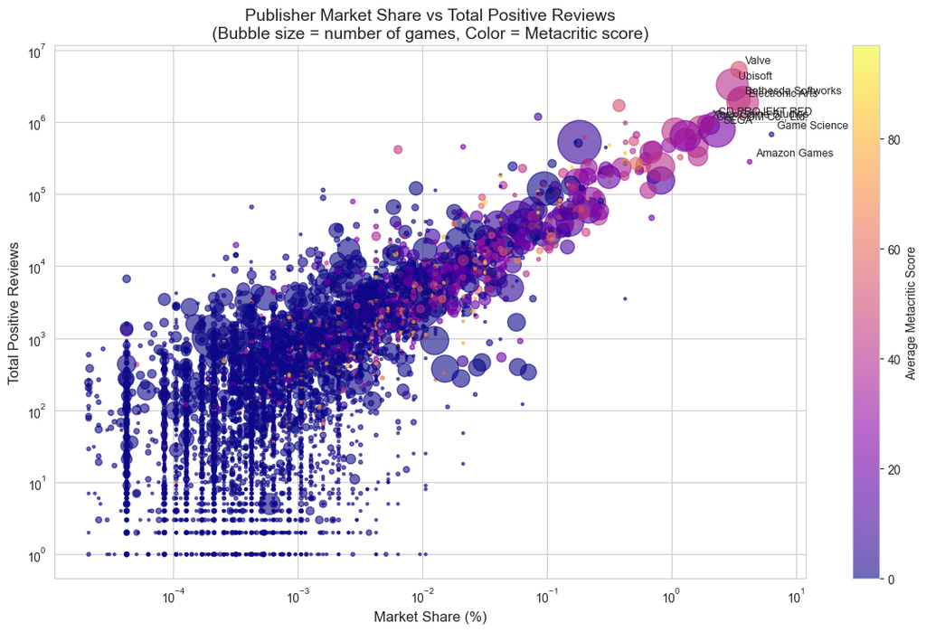

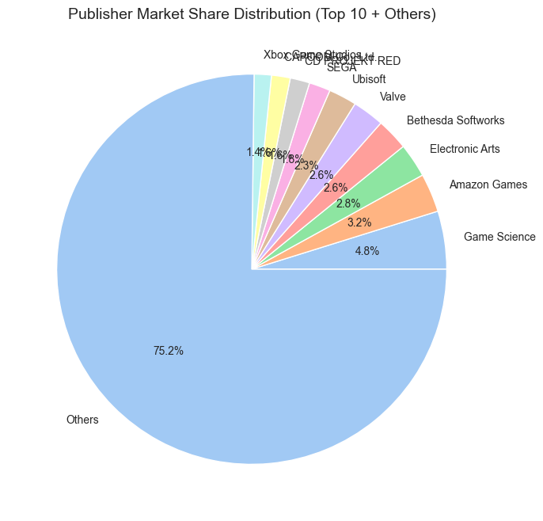

```python
# 设置字体和解决负号显示问题
mpl.rcParams['font.family'] = 'DejaVu Sans'
mpl.rcParams['axes.unicode_minus'] = False
plt.rcParams['font.sans-serif'] = ['DejaVu Sans', 'Arial', 'Helvetica', 'sans-serif']
sns.set_style("whitegrid")



# 数据预处理
def safe_literal_eval(x):
    try:
        if pd.isna(x):
            return []
        return ast.literal_eval(x) if isinstance(x, str) else x
    except:
        return []

# 处理publishers列
df['publishers'] = df['publishers'].apply(safe_literal_eval)
df = df[df['publishers'].apply(len) > 0]

# 展开publisher列表
exploded_df = df.explode('publishers')

# 提取最小用户数
def extract_owners_min(owners_str):
    if pd.isna(owners_str):
        return 0
    try:
        if ' - ' in owners_str:
            return int(owners_str.split(' - ')[0].replace(',', '').replace(' ', ''))
        else:
            return int(owners_str.replace(',', ''))
    except:
        return 0

exploded_df['min_owners'] = exploded_df['estimated_owners'].apply(extract_owners_min)
exploded_df['estimated_revenue'] = exploded_df['price'] * exploded_df['min_owners']

# 按publisher聚合数据
publisher_stats = exploded_df.groupby('publishers').agg({
    'name': 'count',
    'price': 'mean',
    'min_owners': 'sum',
    'estimated_revenue': 'sum',
    'metacritic_score': 'mean',
    'positive': 'sum',
    'negative': 'sum'
}).reset_index()

publisher_stats.columns = ['publisher', 'game_count', 'avg_price', 'total_owners',
                          'estimated_revenue', 'avg_metacritic', 'total_positive', 'total_negative']

# 计算市场份额
total_revenue = publisher_stats['estimated_revenue'].sum()
publisher_stats['market_share'] = (publisher_stats['estimated_revenue'] / total_revenue) * 100
publisher_stats['revenue_rank'] = publisher_stats['estimated_revenue'].rank(ascending=False)

# 计算总评价数量
publisher_stats['total_reviews'] = publisher_stats['total_positive'] + publisher_stats['total_negative']


# 1. 前20大Publisher市场份额
top_20_publishers = publisher_stats.nlargest(20, 'market_share')

plt.figure(figsize=(16, 10))
bars = plt.barh(top_20_publishers['publisher'], top_20_publishers['market_share'], alpha=0.7, color='lightcoral')
plt.xlabel('Market Share (%)', fontsize=12)
plt.ylabel('Publisher', fontsize=12)
plt.title('Top 20 Publishers by Market Share', fontsize=14)

# 添加市场份额数值标签
for bar in bars:
    width = bar.get_width()
    plt.text(width + 0.1, bar.get_y() + bar.get_height()/2,
             f'{width:.2f}%', ha='left', va='center', fontsize=10)

plt.gca().invert_yaxis()
plt.tight_layout()
plt.show()

# 2. 前15大Publisher总好评数量
top_15_positive = publisher_stats.nlargest(15, 'total_positive')

plt.figure(figsize=(14, 8))
bars = plt.barh(top_15_positive['publisher'], top_15_positive['total_positive'], color='lightblue')
plt.xlabel('Total Positive Reviews', fontsize=12)
plt.title('Top 15 Publishers by Total Positive Reviews', fontsize=14)

# 添加好评数量数值标签
for bar in bars:
    width = bar.get_width()
    plt.text(width + 0.1, bar.get_y() + bar.get_height()/2,
             f'{width:,.0f}', ha='left', va='center', fontsize=10)

plt.gca().invert_yaxis()
plt.tight_layout()
plt.show()

# 3. 散点图：市场份额 vs 总好评数量
plt.figure(figsize=(14, 8))

filtered_stats = publisher_stats[publisher_stats['total_positive'] > 0]

scatter = plt.scatter(filtered_stats['market_share'], filtered_stats['total_positive'],
                     s=filtered_stats['game_count']*5, alpha=0.6,
                     c=filtered_stats['avg_metacritic'], cmap='plasma')

plt.xlabel('Market Share (%)', fontsize=12)
plt.ylabel('Total Positive Reviews', fontsize=12)
plt.title('Publisher Market Share vs Total Positive Reviews\n(Bubble size = number of games, Color = Metacritic score)', fontsize=14)
plt.colorbar(label='Average Metacritic Score')

# 标注前10大Publisher
for i, row in filtered_stats.nlargest(10, 'market_share').iterrows():
    plt.annotate(row['publisher'], (row['market_share'], row['total_positive']),
                xytext=(5, 5), textcoords='offset points', fontsize=9)

plt.xscale('log')
plt.yscale('log')
plt.show()

# 4. Publisher市场份额分布饼图
top_10_publishers = publisher_stats.nlargest(10, 'market_share')
others = pd.DataFrame({
    'publisher': ['Others'],
    'market_share': [publisher_stats['market_share'][10:].sum()]
})
pie_data = pd.concat([top_10_publishers[['publisher', 'market_share']], others])

plt.figure(figsize=(12, 8))
plt.pie(pie_data['market_share'], labels=pie_data['publisher'], autopct='%1.1f%%')
plt.title('Publisher Market Share Distribution (Top 10 + Others)', fontsize=14)
plt.show()
```

## 5. 🎭 Game Content Analysis

- Genre and tag analysis
  - Main game genres distribution
  - Popular tags analysis
  - Genre-tag association mining
- Multi-language support analysis
  - Relationship between language support and market reach
  - Full audio support game characteristics